# Efficient Leroux model in Stan

By James Hogg - 2023

# Introduction

This document details the Leroux conditional autoregressive (LCAR) models in Stan. Building on previous work in sparse implementations of CAR models in Stan, we show that our approach can give considerable efficiency gains, scaling better for large spatial data sets.This vignette shows how the multivariate LCAR implementation given here can be used in the univariate case.

# The Leroux spatial model

Although CAR models have been used for decades to model the spatial dependence between lattice spatial data, the model proposed by Leroux [1] has gained considerable attention given its nice properties. Suppose we have aggregated disease count data $y_1, y_2, \dots, y_M$ at $M$ locations, and we expect that neighbouring locations will have similar counts. Standard disease mapping assumes a Poisson likelihood of the form:

$$y_i \sim \text{Poisson}\left( \text{exp}\left( \beta + \phi_i + \text{log}\left( E_i \right) \right) \right)$$

where $\beta$ is the overall intercept, $\phi_i$ are the spatial random effects which follow a Leroux prior (discussed below) and $E_i$ gives the expected counts which are included to account for differences in expected values or exposures in the small areas.

Using the Leroux CAR prior for $\boldsymbol{\phi} = \left( \phi_1, \dots, \phi_M \right)$, results in a multivariate Gaussian distribution of the form:

$$\boldsymbol{\phi} \sim \text{MVN}\left( \boldsymbol{0}, \boldsymbol{\Omega}^{-1} \right)$$

where $\boldsymbol{\Omega} = \frac{1}{\tau^2}[\rho\left( \boldsymbol{D} - \boldsymbol{W} \right) + (1-\rho)]$ is the precision matrix of size $M \times M$. With some simplifications,

$$\begin{align}
\boldsymbol{\Omega} &= \frac{1}{\tau^2} \left[ \rho\left( \boldsymbol{D} - \boldsymbol{W} \right) + (1-\rho) \right]
\\
\boldsymbol{\Omega} &= \frac{1}{\tau^2} \left[ \boldsymbol{I} - \rho \boldsymbol{C} \right]
\end{align}$$
where $\boldsymbol{C} = \boldsymbol{I} - \boldsymbol{D} + \boldsymbol{W}$. Assume the following:

- $\boldsymbol{D}$: an $M \times M$ diagonal matrix with the number of neighbors for each area
- $\boldsymbol{I}$: an $M \times M$ identity matrix
- $\rho$: a spatial autocorrelation parameter that controls the level of spatial dependence ($\rho = 0$ implies spatial independence and $\rho = 1$ collapses to an intrinsic CAR (ICAR) prior which has already been implemented in `Stan`)
- $\boldsymbol{W}$: the $M \times M$ binary contiguity adjacency matrix. $W_{ij} = 1$ if and only if area $i$ is a neighbor of area $j$. All other entries of $\boldsymbol{W}$ are $0$.
- $\tau$ is the marginal standard deviation of the Leroux random effects

To facilitate a fair comparison with `CARBayes`, we assume the following priors throughout the analysis.
$$\begin{align}
\tau^2 &\sim \text{Inverse-Gamma}\left( 1,0.5 \right)
\\
\rho &\sim \text{Uniform}\left( 0,1 \right)
\\
\beta &\sim \text{N}\left( 0,1 \right)
\end{align}$$

# Example: Scottist lip cancer data

Like many vignettes on disease mapping, to demonstrate this approach we will use the Scottish lip cancer data example. This data set includes observed lip cancer case counts at 56 spatial units in Scotland, with an expected number of cases to be used as an offset. The model structure is identical to the Poisson model outlined above.

```r
# Load data from CARBayesdata package
data(lipdata)
data(lipdbf)
data(lipshp)
lipdbf$dbf <- lipdbf$dbf[ ,c(2,1)]
data <- st_as_sf(combine.data.shapefile(data=lipdata, shp=lipshp, dbf=lipdbf))

# create weight matrices
W <- nb2mat(poly2nb(data), zero.policy = FALSE, style = "B")

# create design matrix
data$scaled_x <- c(scale(data$pcaff))
X <- model.matrix(~data$scaled_x)
```

## Standard CARBayes implementation: LCAR with `S.CARleroux`

```r
m_s <- Sys.time()
cb_fit <- myfuns$fitLeroux_mc(observed ~ offset(log(expected)) + scaled_x,
                              data = data, family = "poisson",
                              burnin = 4000, n.sample = 6000,
                              thin = 1, W = W,
                              n.chains = 4) # n.chains not native to CARBayes
(cb_rt <- as.numeric(Sys.time() - m_s, units = "mins"))
```

```
## [1] 0.05919787
```

```r
# summarise draws
cb_summ <- myfuns$summaryLeroux_mc(cb_fit) %>%
  mutate(bess_pm = ess_bulk/cb_rt,
         tess_pm = ess_tail/cb_rt)
```

## Naive Stan implementation: LCAR with `multi_normal_prec`

Stan model:

```r
"
data{
    int<lower=1> M;                 // number of areas
    int y[M];
    vector[M] E;
    matrix[M, 2] X;
    matrix[M, M] C;
}
transformed data{
    vector[M] zeros = rep_vector(0, M);
}
parameters{
    real<lower=0> tau2; // marginal variance
    real<lower=0,upper=1> rho;
    vector[2] bbeta;
    vector[M] phi;
}
model{
    // likelihood model
    y ~ poisson_log(log(E) + X * bbeta + phi);

    // priors
    tau2 ~ inv_gamma( 1, 0.5); // marginal variance
    bbeta ~ std_normal( );
    rho ~ uniform( 0, 1);

    // naive implementation of leroux
    phi ~ multi_normal_prec( zeros, ( 1.0 ./ tau2 ) * add_diag( - rho * C, 1 ) );
}
"
```

Fit model:

```r
# data list
C_for_stan <- myfuns$prep4MCAR(W, type = "lcar")
d_stan <- list(M = nrow(data), y = data$observed,
               E = data$expected, C = C_for_stan$C,
               X = X)

# fit the Leroux model
m_s <- Sys.time()
sn_fit <- sampling(object = sn_comp,
                  data = d_stan,
                  chains = 4, iter = 6000, warmup = 4000,
                  cores = 4, refresh = 0)
(sn_rt <- as.numeric(Sys.time() - m_s, units = "mins"))
```

```
## [1] 1.35807
```

```r
# summarize results
sn_its <- rstan::extract(sn_fit)
sn_summ <- summarise_draws(sn_fit) %>%
  mutate(bess_pm = ess_bulk/sn_rt,
         tess_pm = ess_tail/sn_rt)
```

## Efficient Stan implementation: LCAR with `MLCAR`

Stan model:

```r
"
functions{
/**
* Log probability density of the leroux conditional autoregressive (LCAR) model
* @param x vector of random effects
* @param rho spatial dependence parameter
* @param sigma standard deviation of LCAR
* @param C_w Sparse representation of C
* @param C_v Column indices for values in C
* @param C_u Row starting indices for values in C
* @param offD_id_C_w indexes for off diagonal terms
* @param D_id_C_w indexes for diagonal terms - length M
* @param C_eigenvalues eigenvalues for C
* @param M number of areas
**
@return Log probability density
*/
real LCAR_lpdf(
    vector x,
    real rho,
    real sigma,
    vector C_w ,
    int [] C_v ,
    int [] C_u ,
    int [] offD_id_C_w ,
    int [] D_id_C_w ,
    vector C_eigenvalues,
    int M
    ) {
        vector[M] ldet_C;
        vector [ num_elements(C_w) ] ImrhoC;
        vector[M] A_S;
        // Multiple off-diagonal elements by rho
        ImrhoC [ offD_id_C_w ] = - rho * C_w[ offD_id_C_w ];
        // Calculate diagonal elements of ImrhoC
        ImrhoC [ D_id_C_w ] = 1 - rho * C_w[ D_id_C_w ];
        A_S = csr_matrix_times_vector( M, M, ImrhoC, C_v, C_u, x );
        ldet_C = log1m( rho * C_eigenvalues );
        return -0.5 * (
        M*log( 2 * pi() )
        - ( M * log(1/square(sigma)) + sum( ldet_C ) )
        + 1/square(sigma) * dot_product(x, A_S)
        );
}
}
data{
    int<lower=1> M;                 // number of areas
    int y[M];
    vector[M] E;
    matrix[M, 2] X;
    // sparse components of C matrix
    vector[M] C_eigenvalues;
    int nC_w;
    vector[nC_w] C_w;
    int C_v[nC_w];
    int C_u[M+1];
    int offD_id_C_w[nC_w - M];      // indexes for off diagonal terms
    int D_id_C_w[M];                // indexes for diagonal terms - length M
}
parameters{
    // precision and sigma must be matrices
    real<lower=0> tau2; // marginal variance
    real<lower=0,upper=1> rho;
    vector[2] bbeta;
    vector[M] phi;
}
model{
    // likelihood model
    y ~ poisson_log(log(E) + X * bbeta + sqrt(tau2) * phi);

    // priors
    tau2 ~ inv_gamma( 1, 0.5); // variance
    bbeta ~ std_normal();
    rho ~ uniform( 0, 1);

    // unit Leroux CAR prior
    target += LCAR_lpdf( phi | rho, 1,
    C_w, C_v, C_u,
    offD_id_C_w, D_id_C_w, C_eigenvalues, M);
}
"
```

Fit model:

```r
# data list
C_for_stan <- myfuns$prep4MCAR(W, type = "lcar")
C_for_stan$C <- NULL
d_stan <- list(M = nrow(data), y = data$observed,
               E = data$expected,
               X = X)
d_stan <- c(d_stan, C_for_stan)

# fit the Poisson Leroux model
m_s <- Sys.time()
s_fit <- sampling(object = s_comp,
                  data = d_stan,
                  pars = c("phi_mat", "tau2_v"), include = FALSE,
                  chains = 4, iter = 6000, warmup = 4000,
                  cores = 4, refresh = 0)
(s_rt <- as.numeric(Sys.time() - m_s, units = "mins"))
```

```
## [1] 0.6280394
```

```r
# summarize results
s_its <- rstan::extract(s_fit)
s_summ <- summarise_draws(s_fit) %>%
  mutate(bess_pm = ess_bulk/s_rt,
         tess_pm = ess_tail/s_rt)
```

It took 0.06, 1.36 and 0.63 minutes for the `CARBayes`, naive stan and efficient stan models, respectively.

# MCMC efficiency comparison

Using $\rho$.

| Sampler | Number of effective samples | Elapsed time (mins) | Effecti samples/minute |
| --- | --- | --- | --- |
| CARBayes | 1086.7584 | 0.06 | 18358.0668 |
| Stan: naive | 458.8257 | 1.36 | 337.8512 |
| Stan: efficient | 1255.2935 | 0.63 | 1998.7498 |

# Posterior distribution comparison

We’ll compare the results for the hyper parameters.

```r
rbind(s_summ %>%
  filter(str_detect(variable, "rho|bbeta|tau2")) %>%
  mutate(variable = str_replace(variable, "bbeta", "beta"),
         variable = paste0(variable, " (stan)")),
cb_summ %>%
  filter(str_detect(variable, "rho|beta|tau2")) %>%
  mutate(variable = paste0(variable, " (cb)")),
sn_summ %>%
  filter(str_detect(variable, "rho|bbeta|tau2")) %>%
  mutate(variable = str_replace(variable, "bbeta", "beta"),
         variable = paste0(variable, " (stan naive)"))) %>%
arrange(variable) %>%
dplyr::select(variable, median, sd, rhat, ess_bulk, bess_pm)
```

```
## # A tibble: 12 x 6
##    variable             median     sd  rhat ess_bulk bess_pm
##    <chr>                 <dbl>  <dbl> <dbl>    <dbl>   <dbl>
##  1 beta[1] (cb)         0.0980 0.0516  1.01    778.  13136.
##  2 beta[1] (stan naive) 0.121  0.464   1.08     62.9    46.3
##  3 beta[1] (stan)       0.103  0.337   1.02    283.    450.
##  4 beta[2] (cb)         0.251  0.0902  1.02    180.   3043.
##  5 beta[2] (stan naive) 0.230  0.0919  1.00   2164.   1593.
##  6 beta[2] (stan)       0.237  0.0912  1.00   2099.   3342.
##  7 rho (cb)             0.859  0.124   1.00   1087.  18358.
##  8 rho (stan naive)     0.911  0.109   1.00    459.    338.
##  9 rho (stan)           0.899  0.112   1.00   1255.   1999.
## 10 tau2 (cb)            0.541  0.175   1.00    712.  12030.
## 11 tau2 (stan naive)    0.578  0.189   1.00   1739.   1280.
## 12 tau2 (stan)          0.561  0.183   1.00   1137.   1810.
```

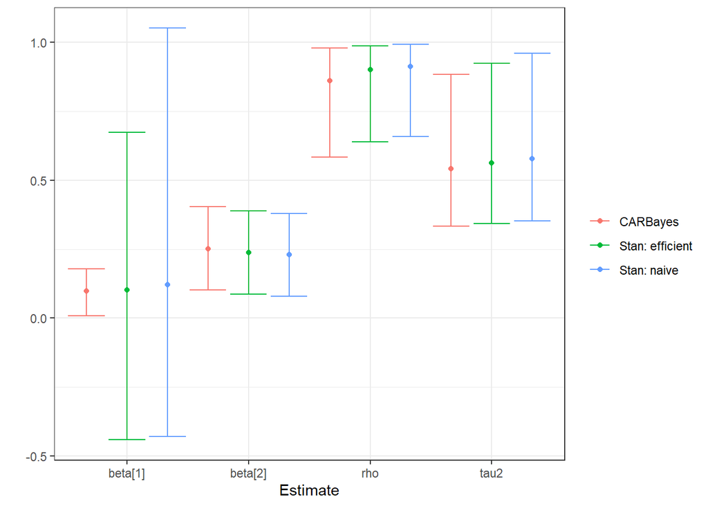

Below we compare the results for the first 9 elements of $\phi$. Take notice of the significant efficient gains that `CARBayes` provides for this simple example.

```
## # A tibble: 27 x 6
##    variable            median    sd  rhat ess_bulk bess_pm
##    <chr>                <dbl> <dbl> <dbl>    <dbl>   <dbl>
##  1 phi[1] (cb)          1.02  0.288  1.01    936.  15819.
##  2 phi[1] (stan naive)  0.991 0.547  1.06     83.1    61.2
##  3 phi[1] (stan)        1.36  0.582  1.01    482.    767.
##  4 phi[2] (cb)          1.08  0.193  1.01    425.   7184.
##  5 phi[2] (stan naive)  1.08  0.497  1.07     61.7    45.4
##  6 phi[2] (stan)        1.45  0.534  1.01    410.    652.
##  7 phi[3] (cb)          0.868 0.269  1.00   1432.  24198.
##  8 phi[3] (stan naive)  0.839 0.537  1.06     84.9    62.5
##  9 phi[3] (stan)        1.16  0.572  1.01    483.    769.
## 10 phi[4] (cb)          0.395 0.331  1.00    591.   9992.
## # ... with 17 more rows
```

We’ll compare the results for the first 20 elements of $\phi$.

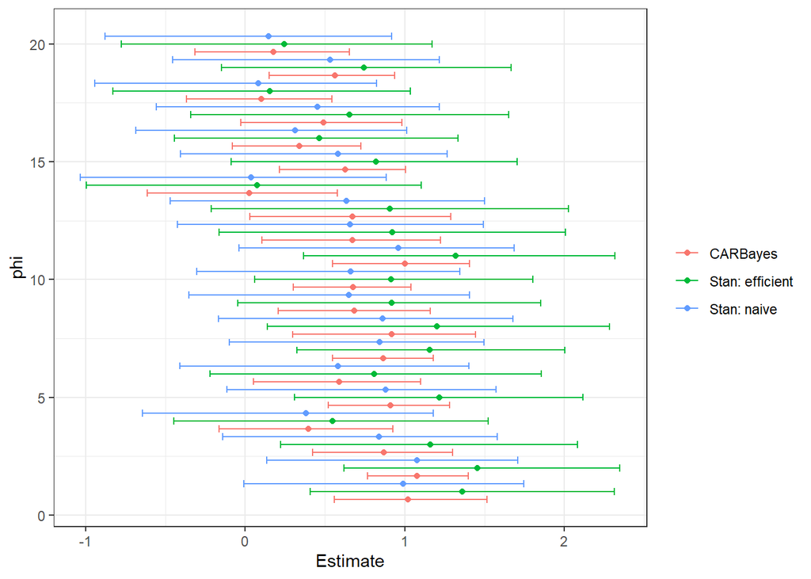

# References

1.

Leroux, B., Lei, X., Breslow, N.: Estimation of disease rates in small areas: A new mixed model for spatial dependence. In: Statistical models in epidemiology, the environment, and clinical trials. pp. 179–191. Springer (2000)